# Eddie Module on stream discharge

# Analyzing stream discharge

This script uses the excel based data sheets from Neversink Creek.

## install libraries - do only one time when first runnign script

```r
# https://github.com/USGS-R/dataRetrieval

# general R packages to install if you dont have them
# remove the "#" if you need to run the installations

# install.packages("devtools") # essential in installing other thigs
# install.packages("tidyverse") # installs a lot of things and ggplot
# install.packages("scales") # allows great scale formatting on ggplot
# install.packages("lubridate") # makes working with dates easier
# install.packages("janitor") # clean names of columns and other things
# install.packages("readxl") # read in excel files
# install.packages("plotly") # interactive plots
# install.packages(skimr)
# devtools::install_github("thomasp85/patchwork") # multiple plots

# specific to this module
# install.packages("dataRetrieval") # USGS Data Retreiveal Method
```

## Load Libraires

```r
# load these every time
library(tidyverse)
library(scales)
library(lubridate)
library(janitor)
library(readxl)
library(skimr)
library(plotly)
library(patchwork)

# # load the USGS package - this is only needed if it uses the USGS retrieval
# library(dataRetrieval)
```

current data https://waterdata.usgs.gov/ny/nwis/uv/?site_no=01435000&PARAmeter_cd=00065,00060,63160

all data https://waterdata.usgs.gov/nwis/inventory/?site_no=01435000&agency_cd=USGS

## Read in file from excel sheet

```r
q.df <- read_excel("../data/stream_discharge_student_dataset.xlsx", # name of the file and path
                 sheet = "Neversink_All_Data", # name of the sheet as it is
                 guess_max = 10000) # helps when there is missing data and guesses for 10k rows
```

## Discharge Graph

this is a graph of discharge in 2013 only. There are several ways to do this but this approach uses the dates you want to see the range of. A year variable could also be made here with mutate(year = year(datetime)) and then filter based on year number only.

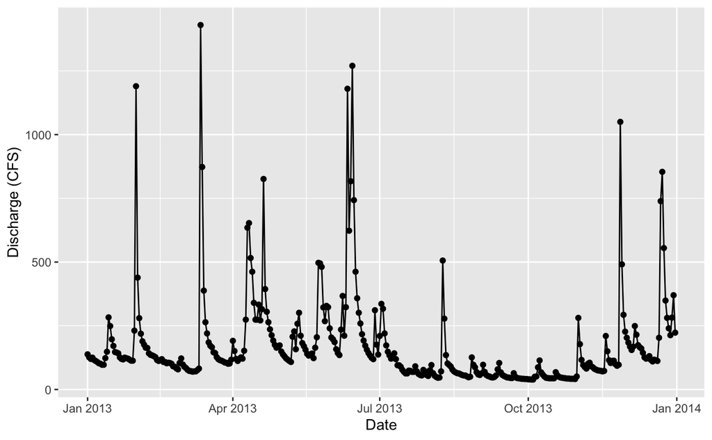

```r
q.df %>% # name of dataframe to get data from to feed into graph
  filter(datetime >= ymd("2013-01-01") & datetime <= ymd("2013-12-31")) %>%  # filters out the date range
  ggplot(aes(x = datetime, y = discharge_cfs)) + # plots discharge versus datatime
  geom_line() + # add lines
  geom_point() + # andd symbols
  labs(y="Discharge (CFS)", x= "Date")
```

## Plot of February Discharge

This is the other way to filter out only a certain year and month combined. Note there is no need to create new dataframes but it can all be done in the piped commands that feed eventually in to the graph.

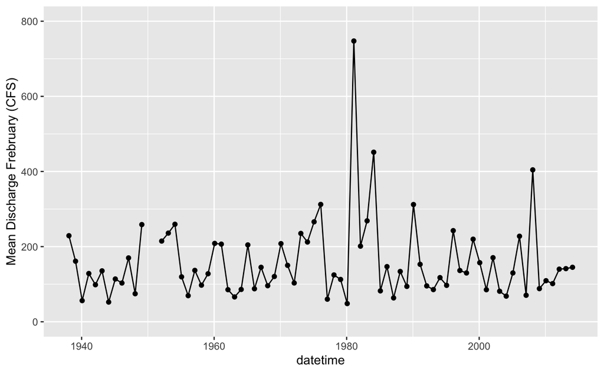

```r
feb.plot <- q.df %>% # store the graph in feb.plot and use the q.df dataset
  mutate( # this allows you to do changes to the data
    month=month(datetime), # create a month variable
    year = year(datetime) # create a year variable
  ) %>%
  filter(month == 2) %>% # filter out only february - month 2
  group_by(year, month) %>% # this is special here... groups by month and year
  summarise(datetime = first(datetime), # gives the first data in the group
            discharge_cfs= mean(discharge_cfs, na.rm=TRUE)) %>%  # takes the average of february discharge
  ggplot(aes(x = datetime, y=discharge_cfs)) + # plot mean discharge versus date time
  geom_line() + # add line
  geom_point() + # add point
  coord_cartesian(ylim = c(0,800))+ # zooms in and y axis goes 0 - 800
  labs(y="Mean Discharge Frebruary (CFS)") # adds labels
feb.plot # calls the plot
```

## Mean Augus Discharge

This does the sam as for February plot above.

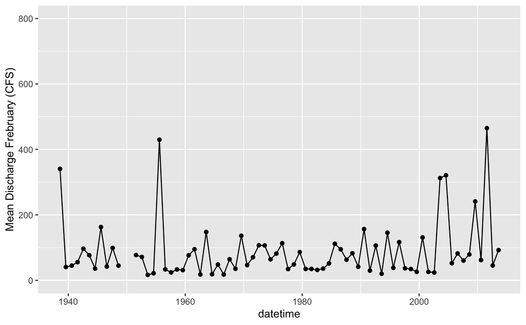

```r
august.plot <- q.df %>%
  mutate(
    month=month(datetime),
    year = year(datetime)
  ) %>%
  filter(month == 8) %>%
  group_by(year, month) %>%
  summarise(datetime = first(datetime),
            discharge_cfs= mean(discharge_cfs, na.rm=TRUE)) %>%
  ggplot(aes(x = datetime, y=discharge_cfs)) +
  geom_line() +
  geom_point() +
  coord_cartesian(ylim = c(0,800))+
  labs(y="Mean Discharge Frebruary (CFS)")
august.plot
```

## Combine February and August plots

This uses patchwork to combine the plots with 2 columns

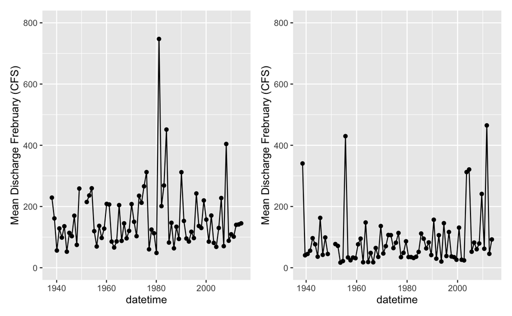

```r
feb.plot +
  august.plot +
  plot_layout(ncol = 2)
```

## Combine plots with regression lines

This combines both plots with regression lines and you could zoom in by adding + coord_cartesian(ylim=c(X,Y)) behind each of the plots to zoom in. This does not remove data for the plots. If you set the limits with scale_y_continuous it would remove data points and change the regression lines.

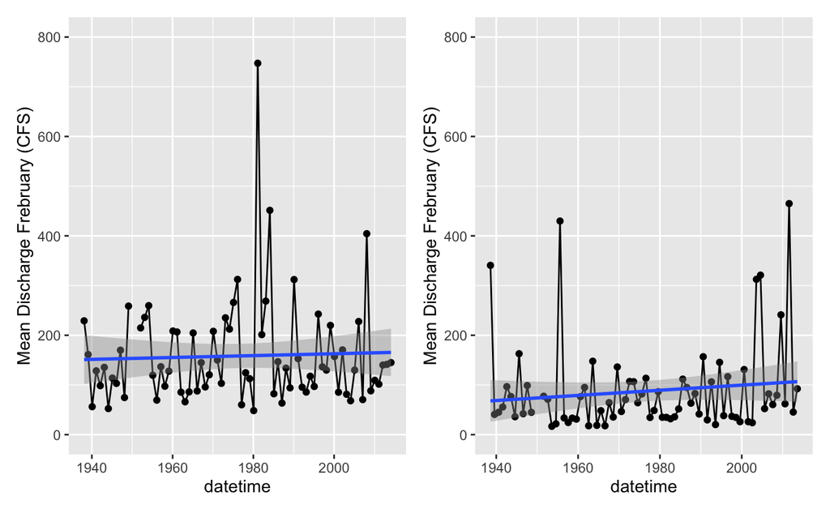

```r
feb.plot + geom_smooth(method="lm") +
  august.plot + geom_smooth(method="lm") +
  plot_layout(ncol = 2)
```

## Regressions of q vs datetime for February

```r
feb.model <- q.df %>%
  mutate(
    month=month(datetime),
    year = year(datetime)
  ) %>%
  filter(month == 2) %>%
  group_by(year, month) %>%
  summarise(datetime = first(datetime),
            discharge_cfs= mean(discharge_cfs, na.rm=TRUE)) %>%
  lm(discharge_cfs ~ datetime, data=.)

summary(feb.model)
```

```
Call:
lm(formula = discharge_cfs ~ datetime, data = .)

Residuals:
    Min      1Q  Median      3Q     Max
-110.66  -66.25  -26.64   50.99  588.10

Coefficients:
             Estimate Std. Error t value Pr(>|t|)
(Intercept) 1.571e+02  1.279e+01  12.283   <2e-16 ***
datetime    5.949e-09  1.752e-08   0.339    0.735
---
Signif. codes:  0 ‘***’ 0.001 ‘**’ 0.01 ‘*’ 0.05 ‘.’ 0.1 ‘ ’ 1

Residual standard error: 106 on 73 degrees of freedom
  (2 observations deleted due to missingness)
Multiple R-squared:  0.001576,  Adjusted R-squared:  -0.0121
F-statistic: 0.1152 on 1 and 73 DF,  p-value: 0.7352
```

## Regressions of q vs datetime for August

```r
aug.model <- q.df %>%
  mutate(
    month=month(datetime),
    year = year(datetime)
  ) %>%
  filter(month == 8) %>%
  group_by(year, month) %>%
  summarise(datetime = first(datetime),
            discharge_cfs= mean(discharge_cfs, na.rm=TRUE)) %>%
  lm(discharge_cfs ~ datetime, data=.)

summary(aug.model)
```

```
Call:
lm(formula = discharge_cfs ~ datetime, data = .)

Residuals:
   Min     1Q Median     3Q    Max
-76.97 -53.52 -26.31  17.97 359.32

Coefficients:
             Estimate Std. Error t value Pr(>|t|)
(Intercept) 8.415e+01  1.089e+01   7.728 4.93e-11 ***
datetime    1.636e-08  1.511e-08   1.083    0.283
---
Signif. codes:  0 ‘***’ 0.001 ‘**’ 0.01 ‘*’ 0.05 ‘.’ 0.1 ‘ ’ 1

Residual standard error: 89.44 on 72 degrees of freedom
  (2 observations deleted due to missingness)
Multiple R-squared:  0.01602,   Adjusted R-squared:  0.002354
F-statistic: 1.172 on 1 and 72 DF,  p-value: 0.2826
```